# Differentiate brush and hover event in Shiny

Zuguang Gu

2021-02-21

[In my last post](https://jokergoo.github.io/2021/02/20/differentiate-brush-and-click-event-in-shiny/) I described how I distinguish click and brush event in `plotOutput` in Shiny. In this post I try to solve another problem which is to differentiate hover and brush event.

Similar as click, brush also intializes a hover event. To distinguish hover and brush, I didn’t use the default hover in `plotOutput`. Here I implement my own one. The implementation contains two parts:

1. the hover event is invoked after the mouse position keeps unchanged for a peroid of time, e.g. 300ms.
2. the brush action starts with a hover action, then instantly, a `div` which corresponds to the brush is created.

For part 1, we need a mouse event which stops at a certain position for a period of time. Here I use [mousestop.js](https://github.com/websanova/mousestop). And for the part 2, we just simply test whether the brush div exists or not.

In the following example code, since `mousestop` does not support a function with event as argument, I additionally use `mousemove` to catch the mouse position and assign in `mousestop`.

```r
library(circlize)
library(GetoptLong)
library(grid)
library(shiny)
library(glue)

ui = fluidPage(
    plotOutput("plot", width = 600, height = 400,
        brush = "brush"),
    includeScript(path = "~/Downloads/mousestop-3.0.1/mousestop.min.js"),
    tags$script(HTML("
        var relX = -1;
        var relY = -1;
        $('#plot').mousemove(function(e) {
            var parentOffset = $(this).offset();
            relX = e.pageX - parentOffset.left;
            relY = e.pageY - parentOffset.top;
        }).mousestop(function() {
            if($('#plot_brush').length == 0) {
                Shiny.setInputValue('x', relX);
                Shiny.setInputValue('y', relY);
                Shiny.setInputValue('action', Math.random());
            }
        });
    ")),
    fluidRow(
        column(3, htmlOutput("output1")),
        column(3, htmlOutput("output2"))
    )
)

server = function(input, output, session) {
    output$plot = renderPlot({
        grid.newpage()
        grid.rect()
    })

    observeEvent(input$action, {
        output$output1 = renderText({
            isolate(glue("
<pre style='background-color:{rand_color(1)}'>
a hover:
x = {input$x}
y = {input$y}</pre>"))
        })
    })

    observeEvent(input$brush, {
        output$output2 = renderText({
            isolate(glue("
<pre style='background-color:{rand_color(1)}'>
a brush:
input$brush$coords_css$xmin = {input$brush$coords_css$xmin}
input$brush$coords_css$ymin = {input$brush$coords_css$ymin}
input$brush$coords_css$xmax = {input$brush$coords_css$xmax}
input$brush$coords_css$ymax = {input$brush$coords_css$ymax}</pre>"))
        })
    })
}

shinyApp(ui, server)
```

The demo is in the following figure:

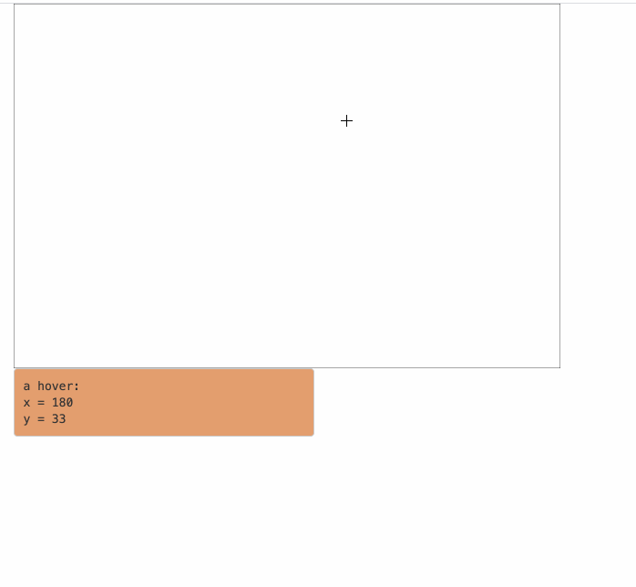